# Prediction Assignnment Writeup

Marie Silvestre

21 septembre 2017

# Load data and packages, & create data partition out of the training set:

```r
#Load relevant packages
library(caret)
library(knitr)
#Load the training and test sets in variable
setwd("/Users/marie/Desktop/Data Science/Machine Learning")
train<-read.csv("pml-training.csv",header=TRUE,sep=",")
test<-read.csv("pml-testing.csv",header=TRUE,sep=",")
#Create a training set and a test set out of the train data
inTrain<-createDataPartition(y=train$classe,p=0.8,list=FALSE)
training<-train[inTrain,]
testing<-train[-inTrain,]
```

# Data processing

## Dimensionnality Reduction

### NAs count and suppression:

First we will change all the factors columns to numeric. Then, we look at the number of NAs in each column and we see that several columns have more than 15000 numbers of NAs (for a total of 15699 obs). We take out those variables from the training and testing data sets.

```r
#Store column names that are factor
col_name_fact<- colnames(training[,sapply(training, is.factor)])
#we remove the first 3 and the last one which we want to keep as factors
col_name_fact<-col_name_fact[4:36]
#change factor columns to numeric in training and testing data sets
training[,col_name_fact]<-lapply(training[,col_name_fact],function(x) as.numeric(as.character(x)))
testing[,col_name_fact]<-lapply(testing[,col_name_fact],function(x) as.numeric(as.character(x)))
#Count numbers of nas in each column
na_count<-apply(training, 2, function(x) (sum(is.na(x))))
na_count<-subset(na_count,na_count!=0)
na_count<-data.frame(na_count)
na_count$names<-rownames(na_count)
head(na_count)
```

```
##                      na_count                names
## kurtosis_roll_belt      15378   kurtosis_roll_belt
## kurtosis_picth_belt     15397  kurtosis_picth_belt
## kurtosis_yaw_belt       15699    kurtosis_yaw_belt
## skewness_roll_belt      15377   skewness_roll_belt
## skewness_roll_belt.1    15397 skewness_roll_belt.1
## skewness_yaw_belt       15699    skewness_yaw_belt
```

```r
#Remove columns with NAs
training<-subset(training,select=colMeans(is.na(training))==0)
testing<-subset(testing,select=colMeans(is.na(testing))==0)
```

We now have only 60 variables left.

### Low Variance:

We will look at the standard deviation from each variable and eliminate low variance variables.

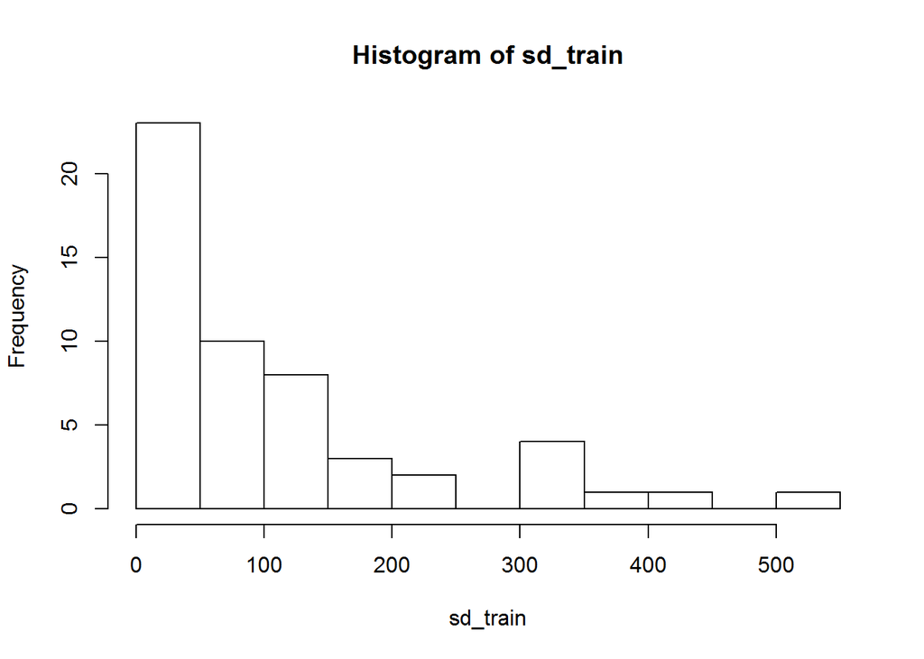

```r
#Calculate variance for each remaining variable in the training set (only for columns 7 to 59)
sd_train<-apply(training[,7:59],2,sd)
hist(sd_train, breaks=10)
```

```r
#Isolate columns with a standard deviation under 50
sd_inf<-sd_train[sd_train < 50]
col_name_sd_inf<-names(sd_inf)
#We remove the columns with a standard deviation < 50 from the training and testing data sets
training<-training[,-which(names(training) %in% col_name_sd_inf)]
testing<-testing[,-which(names(testing) %in% col_name_sd_inf)]
```

We now have 37 variables for the training and testing data sets.

## High correlation

We will look at the correlation between variables and reduce dimensionnality with the PCA.

```r
#Change integer columns to numeric
training[,7:36]<-lapply(training[,7:36],as.numeric)
testing[,7:36]<-lapply(testing[,7:36],as.numeric)
#Find the correlation between predictors
m<-abs(cor(training[,7:36]))
diag(m)<-0
which(m>0.8,arr.ind = TRUE)
```

```
##                  row col
## yaw_belt           3   2
## accel_belt_z       4   2
## roll_belt          2   3
## roll_belt          2   4
## magnet_arm_x      12   9
## accel_arm_x        9  12
## magnet_arm_z      14  13
## magnet_arm_y      13  14
## accel_dumbbell_z  19  16
## yaw_dumbbell      16  19
```

We see a high correlation between several variables. So we can preprocess with PCA and fit the model with the train() function. We will include thresh = 0.85, to keep all the principal component that explain at least 85% of the variance.

## Build Model and cross validation

Since the data is non linear and multi class we will evaluate 4 different algorithms and use the metric “Accuracy” to compare models.

- Classification and regression trees
- Random Forest
- k nearest neighbors
- Linear Discriminant Analysis We wont try SVM since it is better suited to two-class classification problems.

```r
#We don't need the first 6 variables (name, time...)
training<-training[,7:37]
testing<-testing[,7:37]
training$classe<-as.character(training$classe)
testing$classe<-as.character(testing$classe)
#Preprocess with PCA
preProc<-preProcess(training,method="pca",thresh = 0.85)
trainPC<-predict(preProc,training)
#Let us fit our four models: decision tree, random forest, knn and linear discriminant
modelFit_rpart<-train(classe~.,method="rpart",data=trainPC)
modelFit_rf<-train(classe~.,method="rf",data=trainPC)
modelFit_knn<-train(classe~.,method="knn",data=trainPC)
modelFit_lda<-train(classe~.,method="lda",data=trainPC)
#test the models on our testing set
testPC<-predict(preProc,testing)
#And stock the accuracy results in variables
RP<-confusionMatrix(testing$class,predict(modelFit_rpart,testPC))$overall['Accuracy']
RF<-confusionMatrix(testing$class,predict(modelFit_rf,testPC))$overall['Accuracy']
KN<-confusionMatrix(testing$class,predict(modelFit_knn,testPC))$overall['Accuracy']
LDA<-confusionMatrix(testing$class,predict(modelFit_lda,testPC))$overall['Accuracy']
```

Let us see the different accuracies for each model:

```r
#We stock our result in a data frame and print them
acc_res<-data.frame(c(RP,RF,KN,LDA),row.names = c("Decision tree","Random Forest","K nearest neighbors","LDA"))
print(acc_res)
```

```
##                     c.RP..RF..KN..LDA.
## Decision tree                0.3920469
## Random Forest                0.9607443
## K nearest neighbors          0.9337242
## LDA                          0.4769309
```

The Random forest results yields the best accuracy with 96%

We select the Random Forest model as our best model.

# Predict from testing set

```r
testfin<-predict(preProc,test)
reponse<-predict(modelFit_rf,testfin)
reponse
```

```
##  [1] B A C A A E D B A A B C B A E E A B B B
## Levels: A B C D E
```